# Clase práctica

Vamos a utilizar las bases de datos **titanic** y **ecobicis** para realizar un análisis exploratorio.

## Titanic

```r
titanic <- read.csv("Bases de datos/Titanic-Base de datos.csv")
titanic %>% head(10)
```

|  | PassengerId | Survived | Pclass | Name | Sex | Age | SibSp | Parch | Ticket | Fare | Cabin | Embarked |
| --- | --- | --- | --- | --- | --- | --- | --- | --- | --- | --- | --- | --- |
| 1 | 1 | 0 | 3 | Braund, Mr. Owen Harris | male | 22 | 1 | 0 | A/5 21171 | 7.2500 |  | S |
| 2 | 2 | 1 | 1 | Cumings, Mrs. John Bradley (Florence Briggs Thayer) | female | 38 | 1 | 0 | PC 17599 | 71.2833 | C85 | C |
| 3 | 3 | 1 | 3 | Heikkinen, Miss. Laina | female | 26 | 0 | 0 | STON/O2. 3101282 | 7.9250 |  | S |
| 4 | 4 | 1 | 1 | Futrelle, Mrs. Jacques Heath (Lily May Peel) | female | 35 | 1 | 0 | 113803 | 53.1000 | C123 | S |
| 5 | 5 | 0 | 3 | Allen, Mr. William Henry | male | 35 | 0 | 0 | 373450 | 8.0500 |  | S |
| 6 | 6 | 0 | 3 | Moran, Mr. James | male | NA | 0 | 0 | 330877 | 8.4583 |  | Q |
| 7 | 7 | 0 | 1 | McCarthy, Mr. Timothy J | male | 54 | 0 | 0 | 17463 | 51.8625 | E46 | S |
| 8 | 8 | 0 | 3 | Palsson, Master. Gosta Leonard | male | 2 | 3 | 1 | 349909 | 21.0750 |  | S |
| 9 | 9 | 1 | 3 | Johnson, Mrs. Oscar W (Elisabeth Vilhelmina Berg) | female | 27 | 0 | 2 | 347742 | 11.1333 |  | S |
| 10 | 10 | 1 | 2 | Nasser, Mrs. Nicholas (Adele Achem) | female | 14 | 1 | 0 | 237736 | 30.0708 |  | C |

```r
titanic <- titanic %>% mutate(across(c(Survived, Pclass, Embarked), factor))
```

- ¿Los que estuvieron en primera clase tuvieron más posibilidad de sobrevivir que quienes estuvieron en las otras clases?

```r
ggplotly(titanic %>% ggplot(aes(x = Pclass, fill=Survived)) +
            geom_bar() + scale_fill_manual(values=c("gree n4", "purple4")) + theme_bw() + ylab("Cantidad"))
```

[interactive chart not shown]

Se pueden agrupar de otra manera

```r
ggplotly(titanic %>% ggplot(aes(x = Pclass, fill=Survived)) +
            geom_bar(position = "dodge") + scale_fill_manual(values=c("gree n4", "purple4")) + theme_bw() + ylab("Cantidad"))
```

[interactive chart not shown]

O comparar las proporciones

```r
ggplotly(titanic %>% ggplot(aes(x = Pclass, fill=Survived)) +
            geom_bar(position = "fill") + scale_fill_manual(values=c("gree n4", "purple4")) + theme_bw() + ylab("Cantidad"))
```

[interactive chart not shown]

- Comparamos por sexo

```r
ggplotly(titanic %>% ggplot(aes(x = Pclass, fill=Survived)) +
         geom_bar() + scale_fill_manual(values=c("gree n4", "purple4")) + theme_bw() + ylab("Cantidad") +
                      facet_grid(. ~ Sex))
```

[interactive chart not shown]

- ¿Sobrevivieron más mujeres y jóvenes que hombres adultos?

```r
titanic <- titanic %>% mutate(categoria = as.factor(ifelse(Age < 18, "joven", "adulto"))) %>%
          mutate(categoria=fct_relevel(categoria, c("joven", "adulto")))

ggplotly(titanic %>% ggplot(aes(x = categoria, fill=Survived)) +
           geom_bar() + theme_bw() + facet_grid(. ~ Sex))
```

[interactive chart not shown]

- ¿Cuál fue la clase que tuvo mayor variabilidad en cuanto a las edades de los pasajeros?

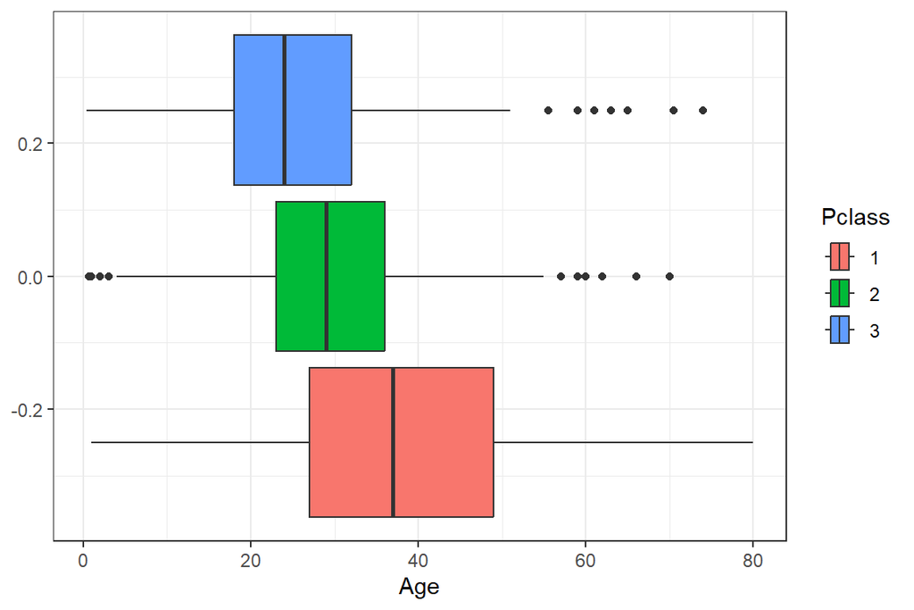

```r
titanic %>% ggplot(aes(Age, fill=Pclass)) + geom_boxplot() + theme_bw()
```

- ¿Hubo diferencias en los costos de los boletos en cada puerto de embarque?

Primero analizamos las distribución de costos de los boletos.

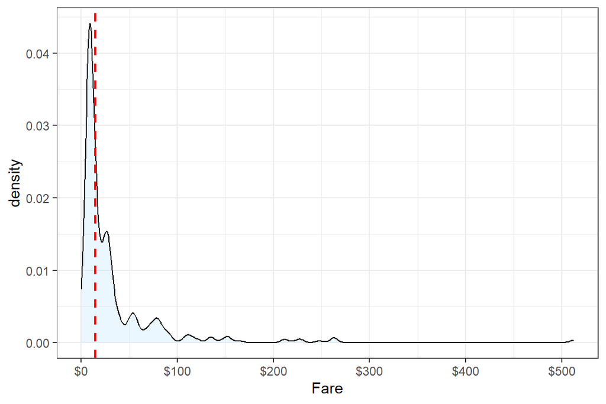

```r
library(scales)

titanic %>% ggplot(aes(x = Fare)) +
  geom_density(fill = '#99d6ff', alpha=0.2) +
  geom_vline(aes(xintercept=median(Fare, na.rm=T)),
             colour='red', linetype='dashed', lwd=0.8) +
  scale_x_continuous(labels=dollar_format()) +
  theme_bw()
```

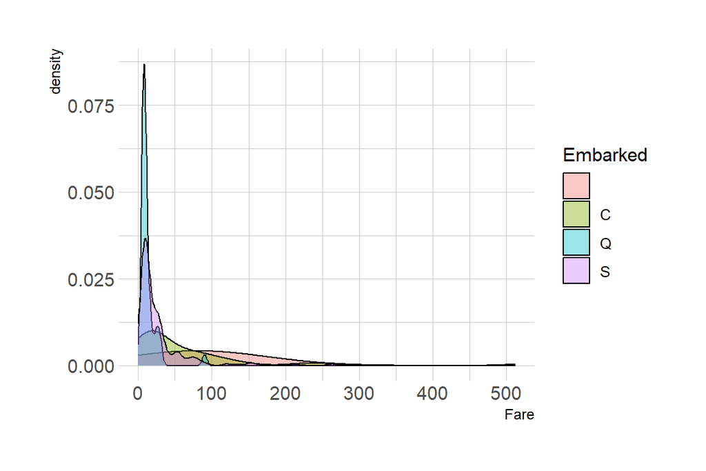

```r
titanic %>% filter(!is.na(Embarked)) %>% ggplot(aes(x=Fare, group=Embarked, fill=Embarked)) +
  geom_density(adjust=1.5, alpha=.4) +
  theme_ipsum()
```

- ¿Existen diferencias entre las distribuciones de las edades entre los que sobrevivieron y no sobrevivieron?

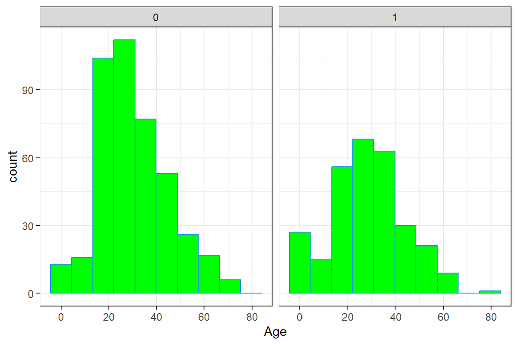

```r
titanic %>% ggplot(aes(Age)) + geom_histogram(bins=10, colour = 4, fill = "green") + theme_bw() + facet_grid(. ~ Survived)
```

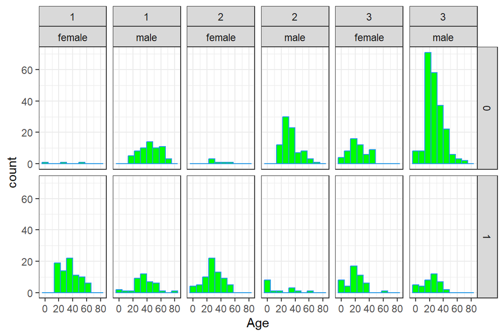

```r
titanic %>% ggplot(aes(Age)) + geom_histogram(bins=10, colour = 4, fill = "green") + theme_bw() + facet_grid(Survived ~ Pclass + Sex)
```

-¿Existe relación entre el costo del ticket y la edad?

```r
ggplotly(titanic %>%
  ggplot(aes(Age, Fare,
             color = Survived)) +
  geom_point() +
  scale_size(range = c(1, 5)) +
  theme_ipsum())
```

[interactive chart not shown]

Por último, vamos a imputar las edades faltantes, utilizando un modelo que las prediga en función de las otras variables.

```r
sum(is.na(titanic$Age))
```

```
## [1] 177
```

```r
library('mice') # imputation

mice_mod <- mice(titanic[, !names(titanic) %in% c('PassengerId','Name','Ticket','Cabin','Survived')], method='rf')
```

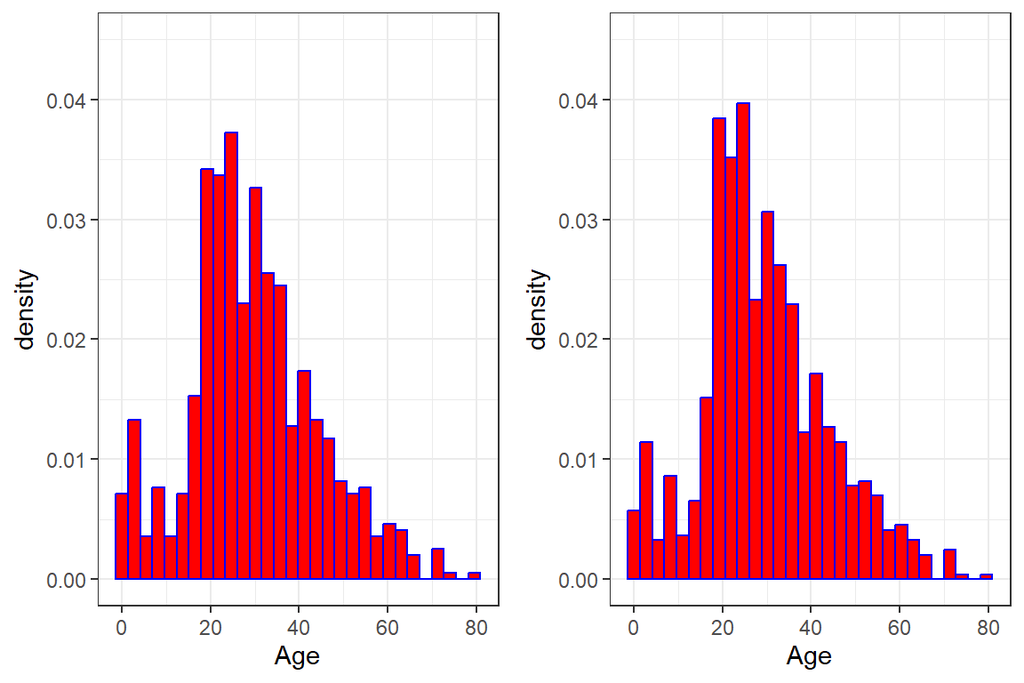

```r
mice_final <- complete(mice_mod)

cowplot::plot_grid(

titanic %>% ggplot(aes(Age)) + geom_histogram(aes(y = ..density..), fill = "red", colour = "blue") +
scale_y_continuous(limits=c(0,0.045)) + theme_bw(),
mice_final %>% ggplot(aes(Age)) + geom_histogram(aes(y = ..density..), fill = "red", colour = "blue") +
  scale_y_continuous(limits=c(0,0.045)) + theme_bw()
)
```

### Nube de palabras

Utilizamos la función **strsplit** y **apply** para extraer el apellido del nombre de la persona

La función strsplit crea subcadenas de una cadena de texto basándose en un separador,

La familia de funciones apply es usada para aplicar una función a cada elemento de una estructura de datos. En particular, es usada para aplicar funciones en matrices, data frames, arrays y listas.

De esta manera se puede automatizar tareas complejas usando poca líneas de código.

La función **sapply()** también realiza operaciones a una lista y a otro tipo de objeto La diferencia con la función apply() es que la función devuelve un vector.

```r
library(wordcloud2)
library(tm)

titanic <- titanic %>% mutate(apellido = sapply(Name,
                              function(x) strsplit(x, split = '[,.]')[[1]][1]))

nube <- titanic %>% group_by(apellido) %>% count() %>%
        rename(word = apellido, freq = n) %>%
        mutate(word = as.factor(word)) %>% filter(freq > 1)

nube <- as.data.frame(nube)
rownames(nube) <- nube$word

wordcloud2(data=nube, size = .2, shape = 'circle')
```

[interactive chart not shown]

- [Referencia nube de palabras](http://rpubs.com/Semilla_389/788115/)

## Base de datos Ecobici

- Visualizar las diferencias, en cuanto al género, de la evolución de la cantidad en el uso de las bicicletas durante el mes de marzo

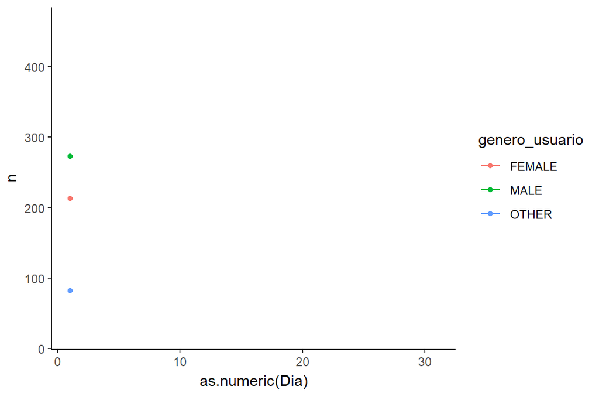

```r
library(gganimate)
library(gifski)

ecobicis <- read.csv("Bases de datos/usuarios_ecobici_2024.csv")

bici_marzo_dia <- ecobicis %>% separate(fecha_alta, c("Año", "Mes", "Dia")) %>%
              filter(Año == "2024" & Mes == "03") %>%
              group_by(Año, Mes, genero_usuario, Dia) %>% count()

anim <- ggplot(
    data = bici_marzo_dia,
    aes(x = as.numeric(Dia), y = n, color = genero_usuario)) +
    geom_line() +
    geom_point() +
    theme_classic() +
    transition_reveal(as.numeric(Dia))

animate(anim, nframes = 200, , fps = 10,
        renderer = gifski_renderer("gganim.gif"))
```

- Detectar cuál fue el horario en el que más se utilizaron las bicicletas.

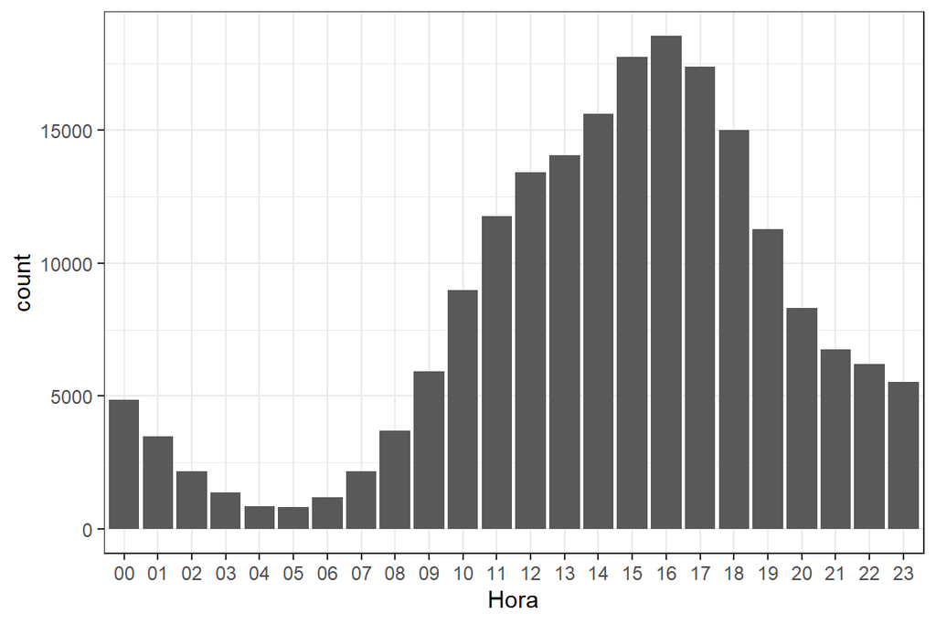

```r
ecobicis %>% separate(hora_alta, c("Hora", "Minutos", "Segundos")) %>%
             ggplot(aes(Hora)) + geom_bar() + theme_bw()
```